# 오바마, 부시 전대통령 연설문 Word Cloud

Hyunsik Yoo

4/20/2017

## 필요한 Library

```r
library(XML)
library(tm)
library(dplyr)
library(xtable)
library(wordcloud)
library(RColorBrewer)
```

## 데이터 가져오기

onetwothree.net에 역대 대통령들의 연설문이 존재합니다. 웹사이트 형태가 연/월/일 형태로 구성되어있기 때문에 입력을 연/월/일로 받아 해당되는 연설문을 추출하여 저장합니다. 2008년 연설문(부시), 2016년 연설문을 추출합니다.

```r
speechtext <- function(ymd){
  sotu <- data.frame(matrix(nrow=1,ncol=3))
  colnames(sotu) = c("speechtext","year","date")
  for(i in 1:length(ymd)){
    year <- substr(ymd[i],1,4)
    url <- paste0('http://stateoftheunion.onetwothree.net/texts/',ymd[i],'.html')
    # 데이터가지고 오기
    doc.html = htmlTreeParse(url, useInternal = TRUE)

    # P태그에 존재하는 텍스트만 추출
    doc.text = unlist(xpathApply(doc.html, '//p', xmlValue))

    # 빈칸으로 구성된 것 또는 의미없는 newline제거
    doc.text = gsub('\\n', ' ', doc.text)
    doc.text = gsub('\\"', '', doc.text)

    doc.text = paste(doc.text, collapse = ' ')

    # 연설문, 연도, 입력받은 data를 columns으로 설정하여 data.frame생성
    x <- data.frame(doc.text, year, ymd[i], stringsAsFactors = FALSE)
    names(x) <- c("speechtext","year","date")
    sotu <- rbind(sotu, x)
    # speechtext가 비어있으면(NA) 필터링
    sotu <- sotu[!is.na(sotu$speechtext), ]
  }
  return(sotu)
}

sotu <- speechtext(c("20080128","20160112"))
```

## 데이터 가공하기

웹에서 가져온 데이터는 raw데이터 입니다. 이를 사용해 WordCloud를 그리기 위해선 데이터 가공이 필요합니다.

여기서 필요한 가공은 다음과 같습니다.

- 세미콜론과 같은 특수문자(구두점) 제거
- 숫자제거
- 빈도수를 계산하기 위해 소문자로 통일
- 조사 제거 (a, an, the….)
- 빈칸제거

tm Library와 duly Library를 사용하여 진행합니다. 데이터 가공 이후 단어 빈도수를 Bush, Obama로 나누어서 하나의 matrix로 만듭니다.

```r
docs <- Corpus(VectorSource(sotu$speechtext)) %>%
  tm_map(removePunctuation) %>%
  tm_map(removeNumbers) %>%
  tm_map(tolower)  %>%
  tm_map(removeWords, stopwords("english")) %>%
  tm_map(stripWhitespace) %>%
  tm_map(PlainTextDocument)

tdm <- TermDocumentMatrix(docs) %>%
  as.matrix()
colnames(tdm) <- c("Bush","Obama")

head(tdm)
```

```
##             Docs
## Terms        Bush Obama
##   abandon       1     0
##   ability       4     0
##   abroad        2     0
##   acceptable    1     0
##   accepts       1     0
##   access        2     0
```

부시 대통령 column을 별도로 추출하여 내림차순으로 정렬

```r
bushsotu <- as.matrix(tdm[,1])
bushsotu <- as.matrix(bushsotu[order(bushsotu, decreasing=TRUE),])
head(bushsotu)
```

```
##          [,1]
## will       54
## america    30
## people     30
## must       29
## congress   27
## new        25
```

마찬가지로 오바마대통령에 대해서도 동일하게 내림차순으로 정렬

```r
obamasotu <- as.matrix(tdm[,2])
obamasotu <- as.matrix(obamasotu[order(obamasotu, decreasing=TRUE),])
head(obamasotu)
```

```
##         [,1]
## thats     30
## world     24
## will      22
## america   21
## people    21
## can       20
```

## Simple Word Cloud 그리기

부시대통령과 오바마대통령에 대한 워드클라우드를 각각 그립니다.

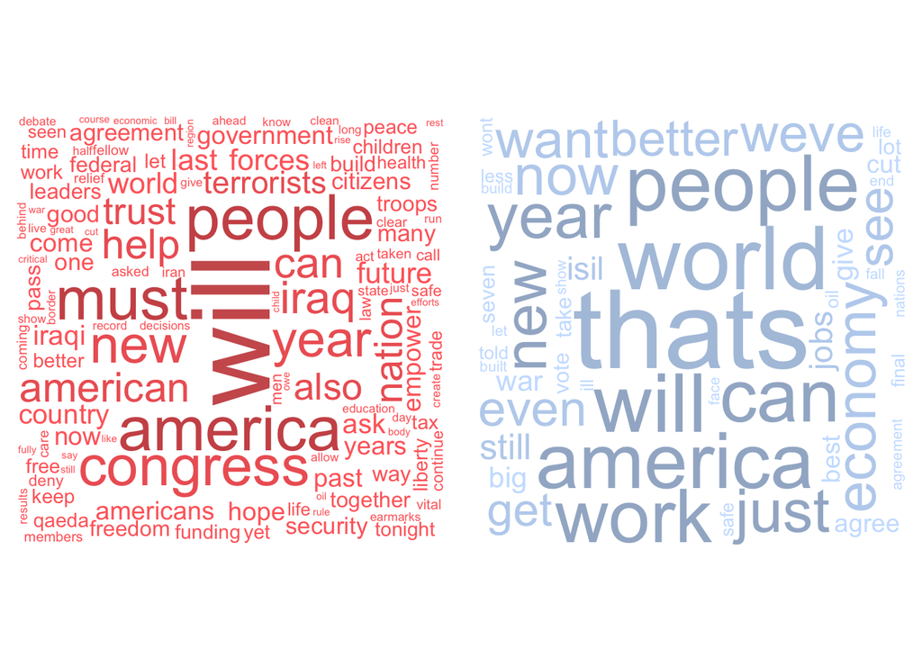

```r
#Create Bush and Obama word clouds and plot them side-by-side
#Create two panels to add the word clouds to
par(mfrow=c(1,2))

wordcloud(rownames(bushsotu), bushsotu, min.freq =3, scale=c(5, .2), random.order = FALSE, random.color = FALSE, colors= c("indianred1","indianred2","indianred3","indianred"))

wordcloud(rownames(obamasotu), obamasotu, min.freq =3, scale=c(5, .2), random.order = FALSE, random.color = FALSE, colors= c("lightsteelblue1","lightsteelblue2","lightsteelblue3","lightsteelblue"))
```

## Comparision Cloud

두개 혹은 두개이상의 문서를 비교할때 사용합니다. 각각의 row별로 더 높은 빈도수를 가진 쪽에 글자를 가시화시킵니다. 위 그래프에서 부시대통령과 오바마대통령모두 america라는 단어를 사용해 모두 출력되었지만 이그래프에서 오바마쪽에 america라는 글자는 없습니다. 이것으로 부시대통령이 america라는 단어를 더 많이 사용했음을 알 수 있습니다.

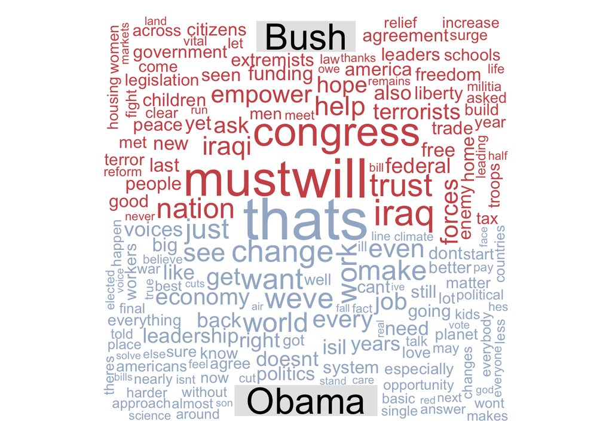

```r
par(mfrow=c(1,1))
comparison.cloud(tdm, random.order=FALSE, colors = c("indianred3","lightsteelblue3"),
                 title.size=2.5, max.words=400)
```

## Commonality Cloud

위 comparison cloud와는 반대로 두개 이상의 문서에 공통으로 들어가있는 단어들에 대해서 만 가시화를 시켜줍니다.

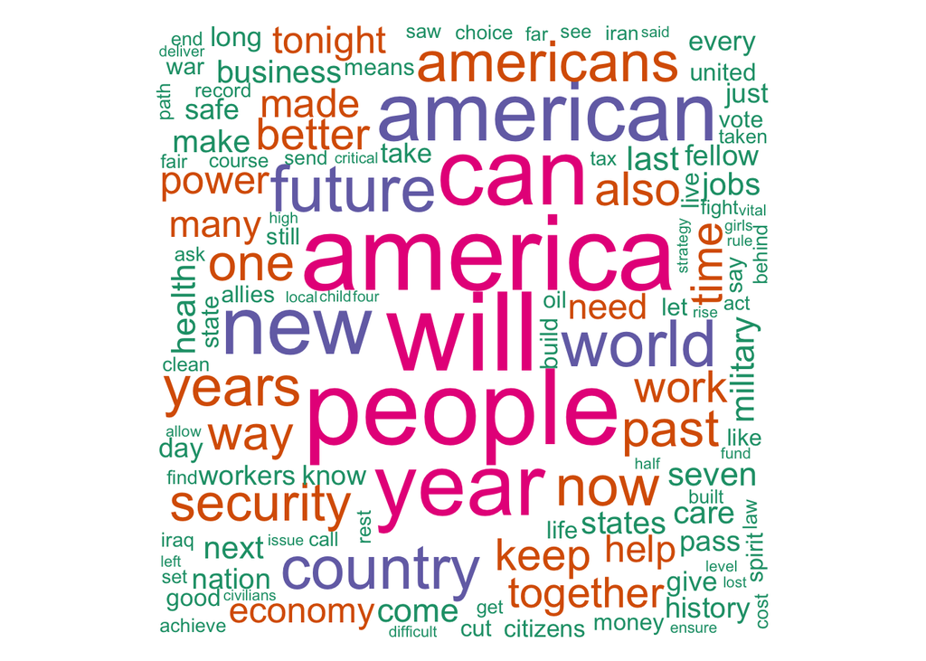

```r
commonality.cloud(tdm, random.order=FALSE, scale=c(5, .5),colors = brewer.pal(4, "Dark2"), max.words=400)
```